# FIFA World Cup Matches Data Visualization

Divyesh Desai - `ddesai7656@floridapoly.edu`

> Importing the required library.

```r
library(dplyr)
library(ggplot2)
```

> Loading the data from the URL and reading it through the imported library.

```r
# Load and read the Wold Cup match data

url <- "../data/WorldCupMatches.csv"
world_cup_data <- read.csv(url, stringsAsFactors = FALSE)
```

> Removing spaces from column names for future use.

```r
# Remove spaces from column names
colnames(world_cup_data) <- gsub(" ", "", colnames(world_cup_data))
```

> Printing the structure of the data.

```r
# Explore the structure of the data

str(world_cup_data)
```

```
'data.frame':   4572 obs. of  20 variables:
 $ Year                : int  1930 1930 1930 1930 1930 1930 1930 1930 1930 1930 ...
 $ Datetime            : chr  "13 Jul 1930 - 15:00 " "13 Jul 1930 - 15:00 " "14 Jul 1930 - 12:45 " "14 Jul 1930 - 14:50 " ...
 $ Stage               : chr  "Group 1" "Group 4" "Group 2" "Group 3" ...
 $ Stadium             : chr  "Pocitos" "Parque Central" "Parque Central" "Pocitos" ...
 $ City                : chr  "Montevideo " "Montevideo " "Montevideo " "Montevideo " ...
 $ Home.Team.Name      : chr  "France" "USA" "Yugoslavia" "Romania" ...
 $ Home.Team.Goals     : int  4 3 2 3 1 3 4 3 1 1 ...
 $ Away.Team.Goals     : int  1 0 1 1 0 0 0 0 0 0 ...
 $ Away.Team.Name      : chr  "Mexico" "Belgium" "Brazil" "Peru" ...
 $ Win.conditions      : chr  " " " " " " " " ...
 $ Attendance          : int  4444 18346 24059 2549 23409 9249 18306 18306 57735 2000 ...
 $ Half.time.Home.Goals: int  3 2 2 1 0 1 0 2 0 0 ...
 $ Half.time.Away.Goals: int  0 0 0 0 0 0 0 0 0 0 ...
 $ Referee             : chr  "LOMBARDI Domingo (URU)" "MACIAS Jose (ARG)" "TEJADA Anibal (URU)" "WARNKEN Alberto (CHI)" ...
 $ Assistant.1         : chr  "CRISTOPHE Henry (BEL)" "MATEUCCI Francisco (URU)" "VALLARINO Ricardo (URU)" "LANGENUS Jean (BEL)" ...
 $ Assistant.2         : chr  "REGO Gilberto (BRA)" "WARNKEN Alberto (CHI)" "BALWAY Thomas (FRA)" "MATEUCCI Francisco (URU)" ...
 $ RoundID             : int  201 201 201 201 201 201 201 201 201 201 ...
 $ MatchID             : int  1096 1090 1093 1098 1085 1095 1092 1097 1099 1094 ...
 $ Home.Team.Initials  : chr  "FRA" "USA" "YUG" "ROU" ...
 $ Away.Team.Initials  : chr  "MEX" "BEL" "BRA" "PER" ...
```

> Printing the first few rows of the data.

```r
# Explore the first few rows of the data

head(world_cup_data)
```

|  | Year | Datetime | Stage | Stadium | City | Home.Team.Name | Home.Team.Goals | Away.Team.Goals | Away.Team.Name | Win.conditions | Attendance | Half.time.Home.Goals | Half.time.Away.Goals | Referee | Assistant.1 | Assistant.2 | RoundID | MatchID | Home.Team.Initials | Away.Team.Initials |
| --- | --- | --- | --- | --- | --- | --- | --- | --- | --- | --- | --- | --- | --- | --- | --- | --- | --- | --- | --- | --- |
| 1 | 1930 | 13 Jul 1930 - 15:00 | Group 1 | Pocitos | Montevideo | France | 4 | 1 | Mexico |  | 4444 | 3 | 0 | LOMBARDI Domingo (URU) | CRISTOPHE Henry (BEL) | REGO Gilberto (BRA) | 201 | 1096 | FRA | MEX |
| 2 | 1930 | 13 Jul 1930 - 15:00 | Group 4 | Parque Central | Montevideo | USA | 3 | 0 | Belgium |  | 18346 | 2 | 0 | MACIAS Jose (ARG) | MATEUCCI Francisco (URU) | WARNKEN Alberto (CHI) | 201 | 1090 | USA | BEL |
| 3 | 1930 | 14 Jul 1930 - 12:45 | Group 2 | Parque Central | Montevideo | Yugoslavia | 2 | 1 | Brazil |  | 24059 | 2 | 0 | TEJADA Anibal (URU) | VALLARINO Ricardo (URU) | BALWAY Thomas (FRA) | 201 | 1093 | YUG | BRA |
| 4 | 1930 | 14 Jul 1930 - 14:50 | Group 3 | Pocitos | Montevideo | Romania | 3 | 1 | Peru |  | 2549 | 1 | 0 | WARNKEN Alberto (CHI) | LANGENUS Jean (BEL) | MATEUCCI Francisco (URU) | 201 | 1098 | ROU | PER |
| 5 | 1930 | 15 Jul 1930 - 16:00 | Group 1 | Parque Central | Montevideo | Argentina | 1 | 0 | France |  | 23409 | 0 | 0 | REGO Gilberto (BRA) | SAUCEDO Ulises (BOL) | RADULESCU Constantin (ROU) | 201 | 1085 | ARG | FRA |
| 6 | 1930 | 16 Jul 1930 - 14:45 | Group 1 | Parque Central | Montevideo | Chile | 3 | 0 | Mexico |  | 9249 | 1 | 0 | CRISTOPHE Henry (BEL) | APHESTEGUY Martin (URU) | LANGENUS Jean (BEL) | 201 | 1095 | CHI | MEX |

> After viewing the data, realizing datetime values are in string format, so converting the datetime field to a Date object.

```r
# Convert date column to Date type

world_cup_data$Datetime <- as.POSIXct(world_cup_data$Datetime, format = "%d %b %Y - %H:%M")
head(world_cup_data)
```

|  | Year | Datetime | Stage | Stadium | City | Home.Team.Name | Home.Team.Goals | Away.Team.Goals | Away.Team.Name | Win.conditions | Attendance | Half.time.Home.Goals | Half.time.Away.Goals | Referee | Assistant.1 | Assistant.2 | RoundID | MatchID | Home.Team.Initials | Away.Team.Initials |
| --- | --- | --- | --- | --- | --- | --- | --- | --- | --- | --- | --- | --- | --- | --- | --- | --- | --- | --- | --- | --- |
| 1 | 1930 | 1930-07-13 15:00:00 | Group 1 | Pocitos | Montevideo | France | 4 | 1 | Mexico |  | 4444 | 3 | 0 | LOMBARDI Domingo (URU) | CRISTOPHE Henry (BEL) | REGO Gilberto (BRA) | 201 | 1096 | FRA | MEX |
| 2 | 1930 | 1930-07-13 15:00:00 | Group 4 | Parque Central | Montevideo | USA | 3 | 0 | Belgium |  | 18346 | 2 | 0 | MACIAS Jose (ARG) | MATEUCCI Francisco (URU) | WARNKEN Alberto (CHI) | 201 | 1090 | USA | BEL |
| 3 | 1930 | 1930-07-14 12:45:00 | Group 2 | Parque Central | Montevideo | Yugoslavia | 2 | 1 | Brazil |  | 24059 | 2 | 0 | TEJADA Anibal (URU) | VALLARINO Ricardo (URU) | BALWAY Thomas (FRA) | 201 | 1093 | YUG | BRA |
| 4 | 1930 | 1930-07-14 14:50:00 | Group 3 | Pocitos | Montevideo | Romania | 3 | 1 | Peru |  | 2549 | 1 | 0 | WARNKEN Alberto (CHI) | LANGENUS Jean (BEL) | MATEUCCI Francisco (URU) | 201 | 1098 | ROU | PER |
| 5 | 1930 | 1930-07-15 16:00:00 | Group 1 | Parque Central | Montevideo | Argentina | 1 | 0 | France |  | 23409 | 0 | 0 | REGO Gilberto (BRA) | SAUCEDO Ulises (BOL) | RADULESCU Constantin (ROU) | 201 | 1085 | ARG | FRA |
| 6 | 1930 | 1930-07-16 14:45:00 | Group 1 | Parque Central | Montevideo | Chile | 3 | 0 | Mexico |  | 9249 | 1 | 0 | CRISTOPHE Henry (BEL) | APHESTEGUY Martin (URU) | LANGENUS Jean (BEL) | 201 | 1095 | CHI | MEX |

> Extracting the year from the date and storing it in the Year column.

```r
# Extract year from date

world_cup_data$Year <- as.integer(format(world_cup_data$Datetime, "%Y"))
world_cup_data <- world_cup_data %>% filter(!is.na(Year))
```

### Visualization 1 - Overall total match outcomes

> Summarizing match results based on goal counts and storing them in a separate column.

```r
# Summarizing Data

world_cup_data <- world_cup_data %>%
  mutate(MatchResult = case_when(
    Home.Team.Goals > Away.Team.Goals ~ "Home Win",
    Home.Team.Goals < Away.Team.Goals ~ "Away Win",
    TRUE ~ "Draw"
  ))
```

> Each row represents a match result, so a new data set is created for the plot by counting the number of winning, losing, and drawn matches.

```r
# Creating new data set for the plot

match_outcomes <- world_cup_data %>%
  group_by(MatchResult) %>%
  summarize(total_matches = n())
```

> Plotting a bar chart for the total number of matches versus the total number of match results in the data sets.

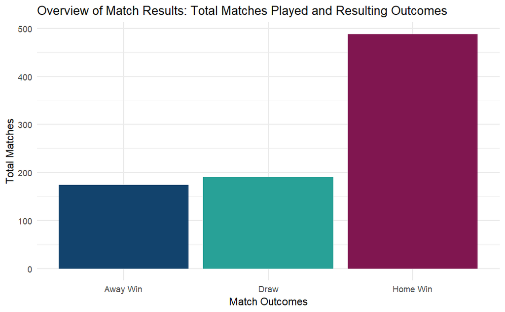

```r
# manual bar colors
bar_colors <- c("#12436d","#28a197" ,"#801650")

ggplot(match_outcomes, aes(x = MatchResult, y = total_matches, fill = bar_colors)) +
  geom_bar(stat = "identity") +
  labs(title = "Overview of Match Results: Total Matches Played and Resulting Outcomes",
       x = "Match Outcomes",
       y = "Total Matches",
       fill = "Match Result") +
  scale_fill_identity() +
  theme_minimal()
```

### Visualization 2 - Average Goals per Match Across World Cup Years

> Each row represents a match, thus a new dataset is created for the plot by calculating the average goals per match per World Cup year.

```r
# Creating new data set for the plot

average_goals_per_match_data <- world_cup_data %>%
  group_by(Year) %>%
  summarize(
    total_matches = n(),
    total_goals = sum(Home.Team.Goals + Away.Team.Goals, na.rm = TRUE),
    average_goals = mean(Home.Team.Goals + Away.Team.Goals, na.rm = TRUE)
  )
```

> plotting the line chart for the Average Goals per Match per World Cup Year

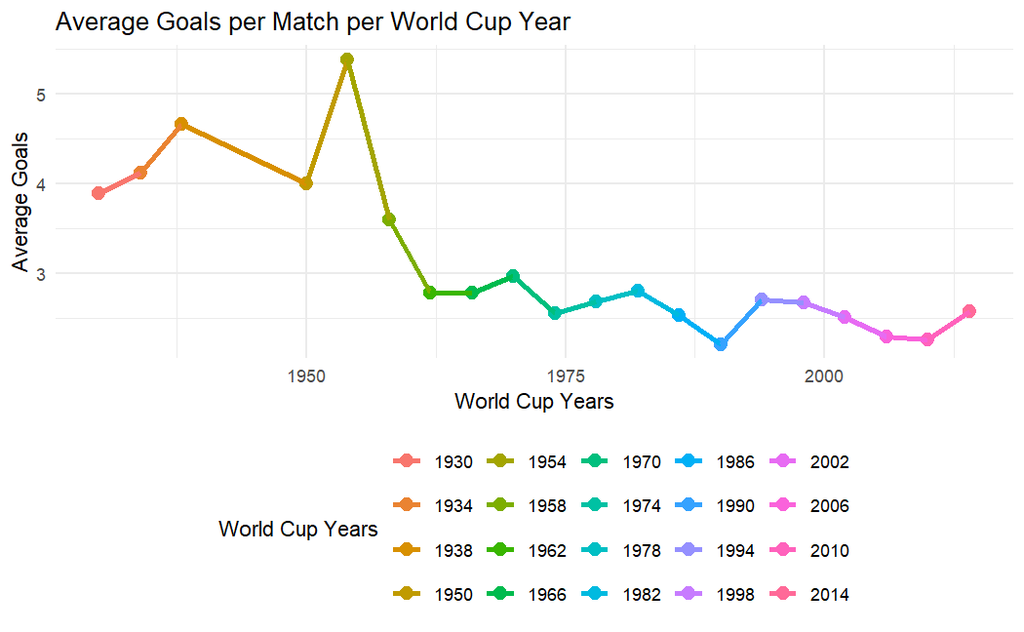

```r
ggplot(data = average_goals_per_match_data, aes(x = Year, y = average_goals, color = as.factor(Year))) +
  geom_point(size = 3) +
  geom_line(aes(group = 1), linewidth = 1.2) +
  labs(title = "Average Goals per Match per World Cup Year", x = "World Cup Years", y = "Average Goals") +
  scale_color_discrete(name = "World Cup Years") +
  theme_minimal() +
  theme(legend.position = "bottom", legend.box = "horizontal")
```

```r
NA
```

### Visualization 3 - Average Home Goals and Away Goals per Match Across World Cup Years

> Summarizing data to create a plot for Average Home Goals and Away Goals per Match Across World Cup Years.

```r
average_home_away_goals_summary <- world_cup_data %>%
  group_by(Year) %>%
  summarize(
    average_home_goals = mean(Home.Team.Goals, na.rm = TRUE),
    average_away_goals = mean(Away.Team.Goals, na.rm = TRUE)
  )
```

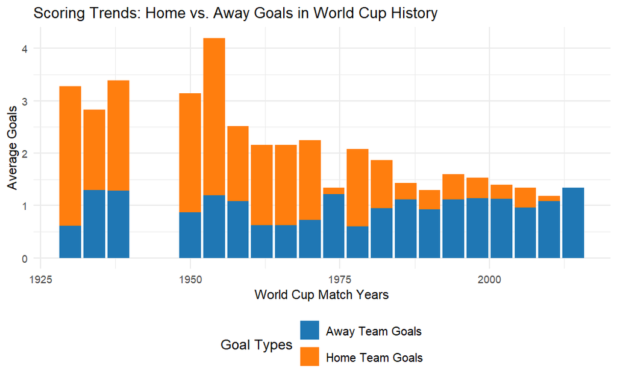

```r
ggplot(data = average_home_away_goals_summary, aes(x = Year)) +
  geom_bar(aes(y = average_home_goals, fill = "Home Team Goals"), stat = "identity", position = "dodge") +
  geom_bar(aes(y = average_away_goals, fill = "Away Team Goals"), stat = "identity", position = "dodge") +
  labs(title = "Scoring Trends: Home vs. Away Goals in World Cup History", y = "Average Goals" , x = "World Cup Match Years") +
  scale_fill_manual(values = c("Home Team Goals" = "#ff7e0e", "Away Team Goals" = "#1f77b4"), name = "Goal Types") +
  theme_minimal() +
  theme(legend.position = "bottom", legend.text = element_text(size = 10), legend.title = element_text(size = 12)) +
  guides(fill = guide_legend(nrow = 2, byrow = TRUE))
```

```r
NA
```